# Northampton tree canopy change 2011-2021

Author

Kent Johnson

### Introduction

NLCD data was obtained from the [Multi-Resolution Land Characteristics Consortium](https://www.mrlc.gov/). An interactive viewer for the underlying data is available [here](https://www.mrlc.gov/viewer).

The NLCD provides data on tree canopy coverage at 30 meter resolution. The percent of canopy coverage is reported for each 30 meter square, with data available for each year from 2011 to 2021.

### Tree canopy in Northampton

This chart shows tree canopy coverage for the City as whole. Overall coverage is approximately 57% for the entire period 2011-2021.

Canopy coverage increased slightly from 2011-2013 to a high of 57.7%, then decreased to a low of 56.6% in 2021, a decline of just over 1%.

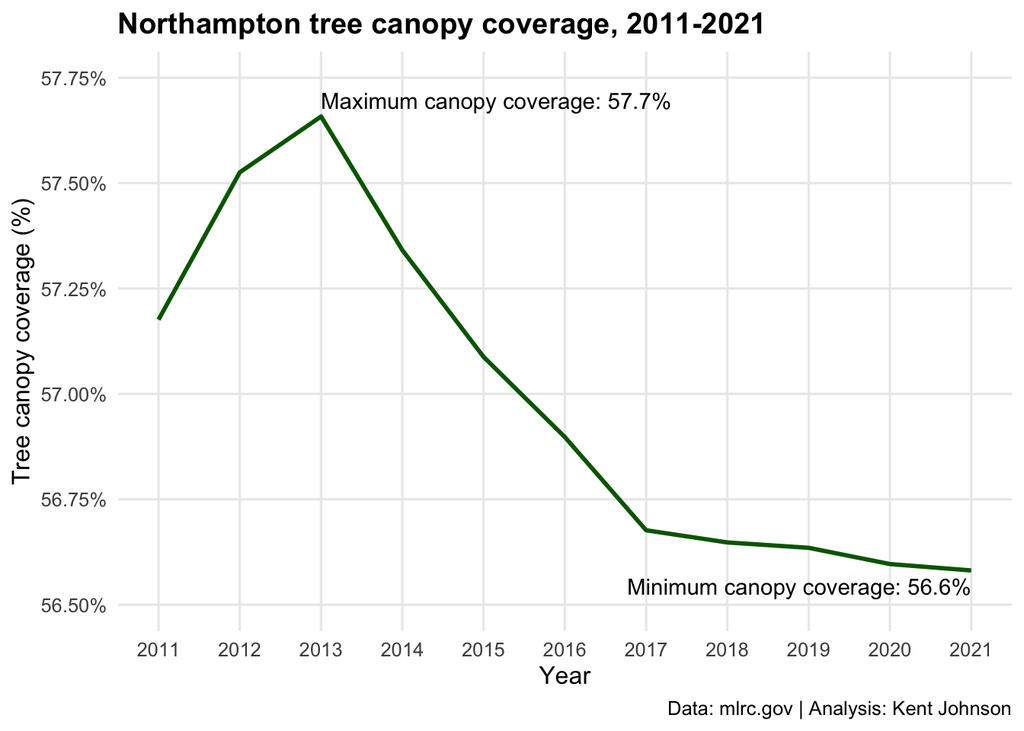

### Tree canopy by zoning category

This chart show the tree canopy percent within five zoning categories aggregated from the City zoning. Unsurprisingly, there is considerable difference in tree canopy coverage across the different zoning categories.

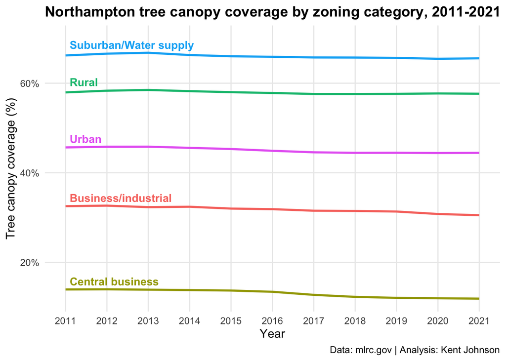

The next chart shows the change in percent tree canopy since the 2011 baseline, by zoning category.

The canopy increase from 2011 to 2013 is mostly in the Rural and Suburban/Water supply zones. All zones have seen a decrease in canopy since 2013. The decrease is largest in the Business/industrial and Central business zones.

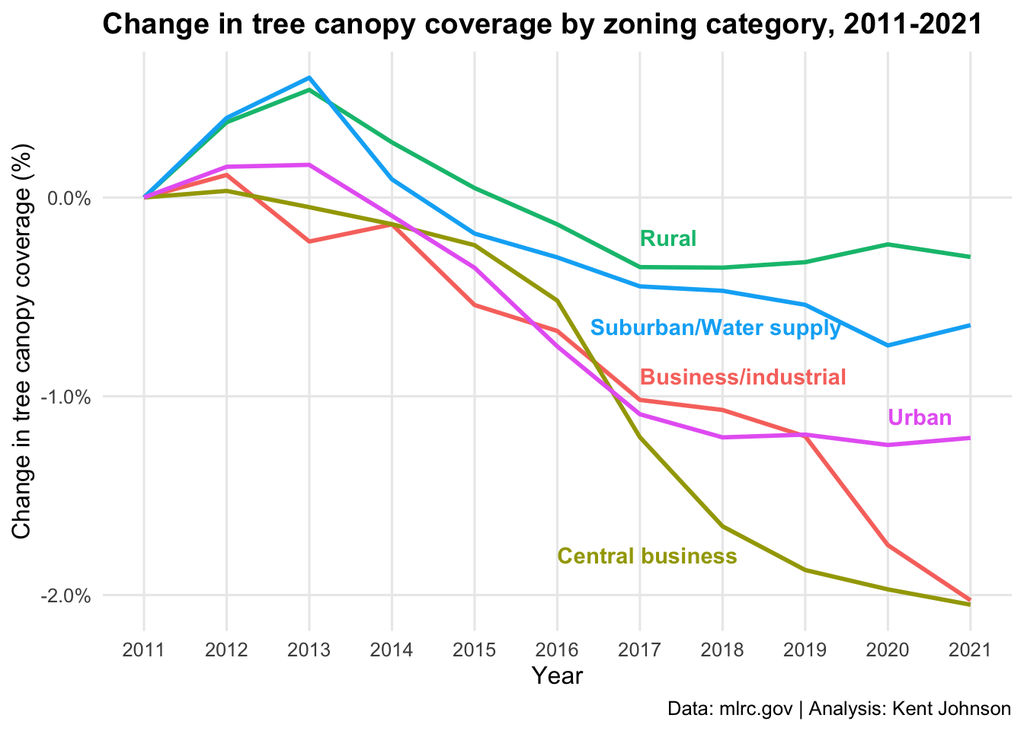

This table shows the canopy coverage in 2011 and 2021 by zone.

Change in tree canopy coverage by zoning category, 2011-2021

| Zoning class | Year 2011 | Year 2021 | Change |  |
| --- | --- | --- | --- | --- |
| Suburban/Water supply | 66.2% | 65.5% |  | −0.6% |
| Rural | 57.9% | 57.6% | −0.3% |  |
| Urban | 45.7% | 44.4% | −1.2% |  |
| Business/industrial | 32.5% | 30.5% | −2.0% |  |
| Central business | 14.0% | 11.9% | −2.0% |  |

Data: [Multi-Resolution Land Characteristics Consortium](https://www.mrlc.gov/) | Analysis: Kent S Johnson

### Zoning map

This map shows the Northampton zoning categories as aggregated for this report.

[interactive chart not shown]

Copyright 2023 Kent S Johnson 2023-07-24